# Populist Pitchforks

Charting the Poptimist Turn in Rock Media

Jonah Wolf

6/15/2020

# Introduction

This paper analyzes the relationship between elite and popular musical tastes by comparing sales data from the Billboard 200 album chart with album scores from the reviews site Pitchfork for the years 1999–2017. While empirical research such as Dewan and Ramaprasad (2014) and Robette (2016) has attempted to quantify the effect of media on music popularity, this paper inverts the relationship to ask how critics respond to mass tastes. In so doing, it hopes to add empirical knowledge to the debates around “poptimism” and “rockism” that permeated metacritical discourse in the early 21st century (see notably Sanneh (2004)).

Founded in 1995, Pitchfork describes itself to advertisers as “the most trusted voice in music” (“Pitchfork. Pitchfork” n.d.). Nonetheless, its influence is difficult to quantify. As Robette writes, “criticism is part of an ensemble of practices of intermediation” (p. 121). He and Beck (2011) cite the same two examples—a 9.7 score for the Arcade Fire (Moore 2004) and an 0.0 for Travis Morrison (Dahlen 2004)—for how the site’s reviews could affect each artists’ careers.

While Robette describes the transmission of Pitchfork’s influence through other sections of the music industry (such as record stores, labels, and other magazines[^1]) (pp. 123–4), Beck remarks that the decline of these institutions, amid the rise of digital music platforms, removes this intermediation: “In the 21st century, we are all record store clerks” (p. 179).

There is a paradox, however, at the root of this influence. As Frith (1981) puts it, “it’s the writers’ independence from record company influence that gives good reviewers their authenticity” (p. 174). The loyalty commanded by any critic depends equally on her independence from prevailing tastes and her reliability in satisfying the tastes of her readership. This paradox is heightened in the field of rock music, and even more so in indie rock—forms that embody “a tension between the music’s aspirations to art and its reality of being a mass, commercial culture” (Hamilton 2016, 80). At the same time, consumers of the rock press—what Frith class “the thinking fan” (p. 172)—are a particularly discerning audience: “for the readers of the rock press, album choices are matters of identity and status, and reviews are of crucial importance—they arouse by far the majority of the responses on the music papers’ letters pages” (p. 173).

# Theoretical framework

Frith’s description of the professionalization of *Rolling Stone* magazine in the 1970s, as it “became integrated into the American music business” (p. 170) anticipates Pitchfork’s trajectory in the 2000s. Robette notes that, between 2003 and 2013, the share of Billboard-charting albums on Pitchfork’s year-end lists increased from 17 to 30%—a phenomenon he calls “a movement of convergence between Pitchfork and the modal taste” (p. 131).

This word “convergence” avoids one-sided explanations of accommodation on the part of either Pitchfork or its audience. Whatever influence the publication had was matched by a broadening of the music it covered. Moreover, this shift in coverage can be attributed as much to ideological reasons as to mercenary ones.

In Pitchfork’s first two decades, critics began to identify a shift in elite musical ideology—what (Peterson and Kern 1996) call “from snob to omnivore” (1996). Peterson and Kern suggest five possible causes for this shift: “structural change” (whereby geographic migration and mass media expose listeners to other cultures), “value change” (the abandonment of status hierarchies of gender, race, religion, and ethnicity), “art-world change” (a shift from conservatizing to “avant-guardist” [sic] ideologies), and “generational politics” (the baby boomers’ continued attachment to the culture of their youth) (p. 905).

For Peterson and Kern, this meant that listeners of “highbrow” classical and opera had increased their fondness for the “lowbrow” genres of country, bluegrass, gospel, rock, and blues (pp. 900–901). In Pitchfork’s case, Beck drolly charts the broadening of coverage beyond white suburban indie rock to include rap, jazz (“’Trane takes it to heaven and back with some style, man” [Schreiber (1999)), and dance music (“You people at shows who don’t dance, who don’t know a good time, who can’t have fun, who sneer and scoff at the supposed inferior—it’s you this music strikes a blow against” (Schreiber 2003)).

# Data

This paper uses a dataset of 18,389 album reviews published on Pitchfork from 1999 through 2016 ((Conaway 2017)). The publication and its authors rate albums on a decimal scale, from 0.0 to 10.0; chosen releases are also assigned the tag “Best New Music.” Albums are tagged with the following genre labels: “electronic,” “metal,” “rock,” “rap,” “experimental,” “pop/r&b,” “folk/country,” “jazz,” and “global.”

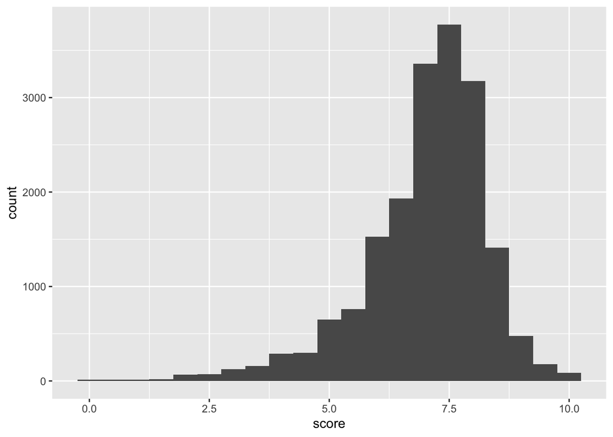

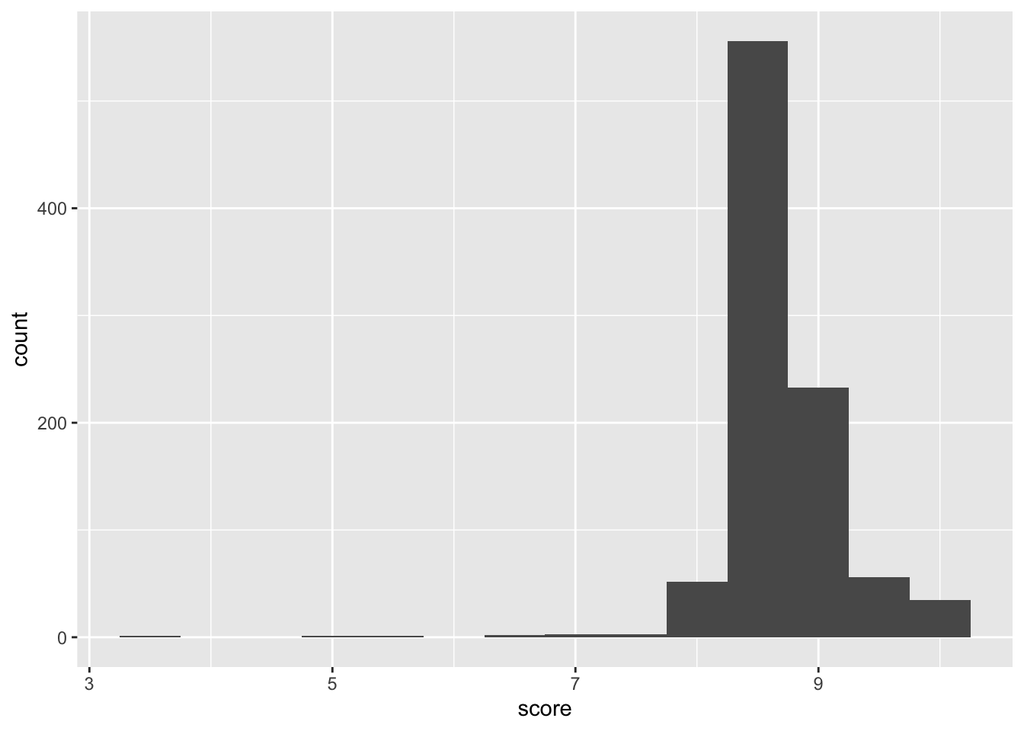

The mean overall score is 7.006, and the median 7.2. For “Best New Music” releases, the mean is 8.676 and median 8.6.[^2]

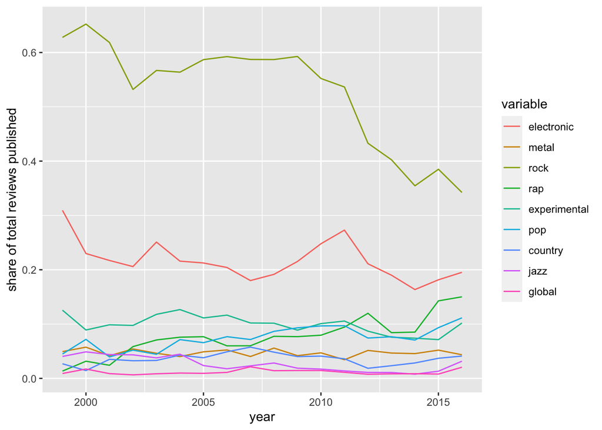

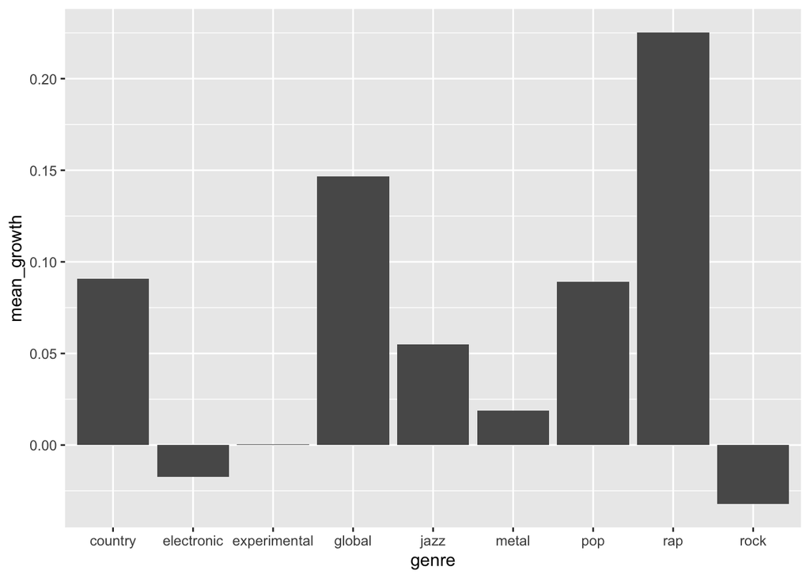

“Rock” has consistently dominated the distribution of genres, though its share of total reviews fell from a majority of 65.2% in 2000 to a strong plurality of 34.2% in 2016 (falling an average of 3.2% each year). By contrast, “rap” grew from 1.3% to 15% over the same period (an average of 22.5% year-over-year), and “pop/R&B” from 4.4% to 11.1% (8.9% average yearly growth).

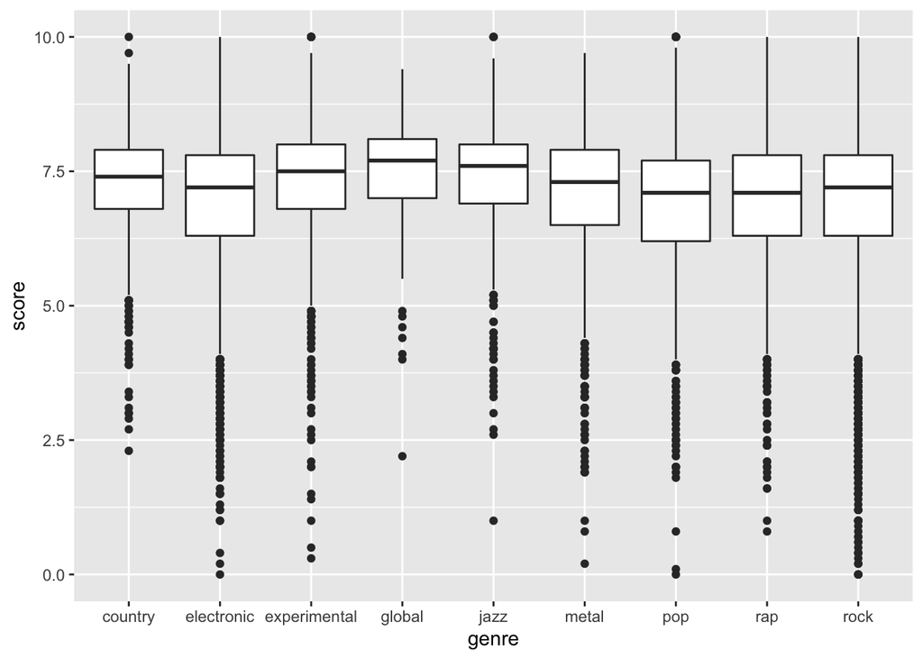

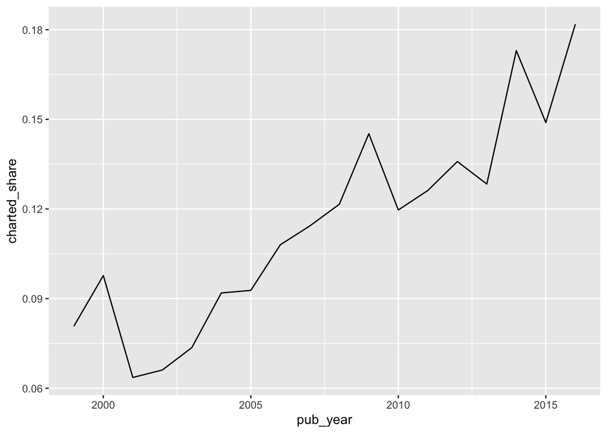

Adding data from the *Billboard* 200, we see that the proportion of coverage given to *Billboard*-charting albums rose from 8% in 1999 to 18% in 2016.